# Forest Change Modeling

Ben DeVries

November 16, 2018

This repository contains data and code for the paper:

DeVries, B., Verbesselt, J., Kooistra L. and Herold, M. 2015. Robust monitoring of small-scale forest disturbances in a tropical montane forest using Landsat time series. Remote Sensing of Environment, 161:107-121, [doi:10.1016/j.rse.2015.02.012](https://doi.org/10.1016/j.rse.2015.02.012)

This paper describes an implementation of the `bfastmonitor` method with Landsat NDVI time series for tracking small-scale forest disturbances in a montane forest in southwestern Ethiopia.

## 1. Cal/Val data

Calibration and validation data were generated using visual interpretation of very high resolution (VHR) SPOT5 and RapidEye imagery. Together, these data formed an annual time series from 2006 to 2012 over the study area. Using the timeSyncR package, randomly sampled pixels were labeled as “deforestation”, “degradation” or “no-change” depending on the changes to the forest canopy observed in the VHR time series.

```r
ref <- read.csv('data/OLR_refdata.csv', row.names = 1)
# convert breakpoints from numeric to factor
ref$breakpoint <- factor(ref$breakpoint)
head(ref)
```

```
##     magnitude breakpoint change_class
## 1 -0.21648168          1          def
## 2 -0.08737494          1    no_change
## 3 -0.04794242          1    no_change
## 4 -0.09516313          1    no_change
## 5 -0.11814548          1    no_change
## 6 -0.05150574          1    no_change
```

The `change_class` column contains the change labels assigned during VHR image interpretation. The `breakpoint` column indicates whether `bfastmonitor` breakpoints occurred (1) or did not occur (0) for that particular pixel. The `magnitude` columns indicates the NDVI change magnitude (ie., the median residual) for that pixel within the 1-year monitoring period window where the breakpoint was detected.

## 2. Ordinal Logistic Regression

Ordinal logistic regression (OLR) was used to test the ability of the `bfastmonitor` breakpoint-magnitude indicators to predict deforestation (complete remove of the forest canopy) and degradation (partial removal of the forest canopy). In this study, OLR models were tested using the change class - deforestation, degradation or no-change - as the response variable and several combinations of breakpoints (binary) and magnitude (continuous) as predictor variables. OLR’s are fit using the `polr()` command in the `MASS` library.

```r
library(MASS)
m0 <- polr(change_class ~ 1, data = ref, method = "probit", Hess = TRUE)  # null model
m1 <- polr(change_class ~ magnitude, data = ref, method = "probit", Hess = TRUE)
m2 <- polr(change_class ~ magnitude + breakpoint, data = ref, method = "probit", Hess = TRUE)
m3 <- polr(change_class ~ breakpoint, data = ref, method = "probit", Hess = TRUE)
```

Here, we fit four models for testing:  
- `m0`: “Null” model (no predictor variables)  
- `m1`: magnitude as a predictor without breakpoints  
- `m2`: magnitude and breakpoints as predictors  
- `m3`: breakpoints only

```r
aic <- AIC(m0, m1, m2, m3)
print(aic)
```

```
##    df      AIC
## m0  2 387.2408
## m1  3 309.5814
## m2  4 305.8929
## m3  3 326.5976
```

Using the Aikaike Information Criterion (AIC), the model that includes both breakpoints and magnitude as predictor variables seems to be the most suitable of the four models, so we will continue with that model.

Next we want to see how these predictor variables affect the probability of the three classes predicted by our model. To do this, we will predict the class probabilities over a range of magnitude values with and without breakpoints.

```r
magns <- seq(min(ref$magnitude), max(ref$magnitude), length = 500)
nd2 <- data.frame(magnitude = rep(magns, 2), breakpoint = factor(c(rep(0, 500), rep(1, 500)), levels = c(0, 1)))
P2 <- predict(m2, newdata = nd2, type = "probs")
nd2$Pdef <- P2[, 1]
nd2$Pdeg <- P2[, 2]
nd2$Pno_change <- P2[, 3]

head(nd2)
```

```
##    magnitude breakpoint      Pdef      Pdeg Pno_change
## 1 -0.2369534          0 0.6342272 0.1885655  0.1772073
## 2 -0.2362581          0 0.6320212 0.1892450  0.1787338
## 3 -0.2355628          0 0.6298108 0.1899207  0.1802685
## 4 -0.2348675          0 0.6275960 0.1905925  0.1818115
## 5 -0.2341722          0 0.6253771 0.1912602  0.1833627
## 6 -0.2334769          0 0.6231540 0.1919238  0.1849222
```

The columns `Pdef`, `Pdeg` and `Pno_change` represent the predicted class probabilities by our `m2` model. We can plot these to analyze the effects of these predictor variables on the class probabilities.

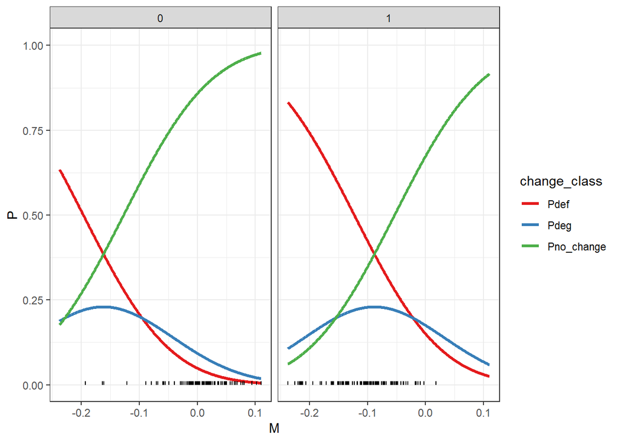

```r
library(ggplot2)
library(reshape2)

nd2m <- melt(nd2, id.vars = c("magnitude", "breakpoint"))
names(nd2m) <- c("magnitude", "breakpoint", "change_class", "P")

p <- ggplot(data = nd2m, aes(x = magnitude, y = P)) +
  geom_line(aes(col = change_class), size = rel(1.2)) +
  scale_y_continuous(limits = c(0, 1)) +
  facet_wrap(~ breakpoint, ncol = 2) +
  labs(x = "M") +
  scale_colour_brewer(palette = "Set1") +
  geom_segment(data = ref, aes(x = magnitude, xend = magnitude), y = 0, yend = 0.01, lwd = 0.5) +
  theme_bw()
p
```

The plots indicate the effect of magnitude on the three class probabilities without breakpoints (left) and with breakpoints (right). The ticks at the bottom of the plot indicate the magnitude values of the sampled pixels. From this plot we can see that even though magnitude has an effect on the probability of detecting degradation, the probability is never sufficiently high to assign a degradation label (the other 2 classes are always more probabable). Therefore, we concluded that using this method, it was not possible to reliably detect degradation, which may be due to the spatial resolution of the Landsat data, limitations in spectral index used (NDVI), limitations in the temporal resolution of the data, or any combination of these or other factors.

## 3. Binomial Logistic Regression